# NFL Salary Analysis

Jeffrey Ngo

2/9/2021

# 1 *Introduction*

The roster of an NFL football team my go through significant changes every year throughout the offseason. Teams may spend more money in different positions than other teams in the league. Throughout the league’s history, different ideologies have been made to reflect how teams won in the past. These ideologies vary from things like “defense win games”, “the league is a passing league, and the Quarterback position is the most important role”, “teams need to win while maximizing rookie contracts.” These are only a few ideas of all the many different takes on NFL football. This analysis will look at how the different ways of spending cap space impacts the number of games a team wins in a season.

This data was scraped from [spotrac](https://www.spotrac.com/nfl/cap/) Steps taken to scrap the data will be added to a separate file and linked to later.

```r
library(tidyverse)
```

```r
library(readxl)
library(ggplot2)
library(knitr)
```

# 2 *Load and Clean Data*

```r
overall_team_salary <- read_excel("C:/Users/My Gaming PC/Desktop/Data Portfolio/NFL Salary Analysis/NFL_Team_Cap_Money.xlsx")

positional_salary <- read_excel("C:/Users/My Gaming PC/Desktop/Data Portfolio/NFL Salary Analysis/NFL_Positions_Team_Spendings.xlsx")

combined_data <- merge(overall_team_salary, positional_salary, by =c("Team", "Year"))

glimpse(combined_data)
```

```
## Rows: 96
## Columns: 20
## $ Team           <chr> "Arizona Cardinals", "Arizona Cardinals", "Arizona C...
## $ Year           <dbl> 2018, 2019, 2020, 2018, 2019, 2020, 2018, 2019, 2020...
## $ Win_Percentage <dbl> 0.188, 0.344, 0.533, 0.438, 0.438, 0.267, 0.625, 0.8...
## $ Signed         <dbl> 53, 53, 53, 53, 52, 53, 53, 53, 53, 53, 53, 51, 53, ...
## $ Avg_Age        <dbl> 25.60, 25.55, 26.43, 27.08, 26.29, 26.42, 25.96, 26....
## $ Active         <dbl> 107921249, 118348287, 135209462, 141338061, 13233735...
## $ Dead           <dbl> 40226555, 50898166, 14812338, 9172909, 18699611, 285...
## $ Total_Cap      <dbl> 172915077, 192155927, 194433178, 173654866, 18424619...
## $ Cap_Space_All  <dbl> 5886709, 1449204, 2094494, 4666533, 5493597, 2978219...
## $ Players        <dbl> 53, 53, 53, 53, 52, 53, 53, 53, 53, 53, 53, 51, 53, ...
## $ QB             <dbl> 5199592, 8296599, 9578101, 22200000, 17205000, 21337...
## $ RB_FB          <dbl> 6795917, 11411398, 10608825, 2054409, 9507891, 10567...
## $ WR             <dbl> 20266148, 16322785, 22890597, 24287868, 12766792, 25...
## $ TE             <dbl> 8270516, 3157867, 5072058, 2155204, 4863357, 2908275...
## $ OL             <dbl> 2602729, 27070307, 29127146, 31191773, 33599165, 355...
## $ DL             <dbl> 22548633, 6306436, 2925535, 20579225, 36402476, 3205...
## $ LB             <dbl> 13513467, 27840082, 28272864, 4516688, 7799521, 1300...
## $ DB             <dbl> 25049762, 14249063, 23442057, 28978875, 8732267, 222...
## $ K_P_LS         <dbl> 3674485, 3693750, 3292279, 5374019, 1460881, 2434435...
## $ Total          <dbl> 107921249, 118348287, 135209462, 141338061, 13233735...
```

The Washington Football Team changed their team name before the 2020 season. To make the data consistent the “Redskins” Will be updated to the “Washington Football Team”. In addition, the column “Total” will be removed, as it is a repeat variable identical to the variable “ACtive.” This occurred when merging the two datasets into the combined dataset.

```r
combined_data[95,1] <- "Washington Football Team"
combined_data[96,1] <- "Washington Football Team"

combined_data <- subset(combined_data, select = c(1:19))

str(combined_data)
```

```
## 'data.frame':    96 obs. of  19 variables:
##  $ Team          : chr  "Arizona Cardinals" "Arizona Cardinals" "Arizona Cardinals" "Atlanta Falcons" ...
##  $ Year          : num  2018 2019 2020 2018 2019 ...
##  $ Win_Percentage: num  0.188 0.344 0.533 0.438 0.438 0.267 0.625 0.875 0.667 0.375 ...
##  $ Signed        : num  53 53 53 53 52 53 53 53 53 53 ...
##  $ Avg_Age       : num  25.6 25.6 26.4 27.1 26.3 ...
##  $ Active        : num  1.08e+08 1.18e+08 1.35e+08 1.41e+08 1.32e+08 ...
##  $ Dead          : num  40226555 50898166 14812338 9172909 18699611 ...
##  $ Total_Cap     : num  1.73e+08 1.92e+08 1.94e+08 1.74e+08 1.84e+08 ...
##  $ Cap_Space_All : num  5886709 1449204 2094494 4666533 5493597 ...
##  $ Players       : num  53 53 53 53 52 53 53 53 53 53 ...
##  $ QB            : num  5199592 8296599 9578101 22200000 17205000 ...
##  $ RB_FB         : num  6795917 11411398 10608825 2054409 9507891 ...
##  $ WR            : num  20266148 16322785 22890597 24287868 12766792 ...
##  $ TE            : num  8270516 3157867 5072058 2155204 4863357 ...
##  $ OL            : num  2602729 27070307 29127146 31191773 33599165 ...
##  $ DL            : num  22548633 6306436 2925535 20579225 36402476 ...
##  $ LB            : num  13513467 27840082 28272864 4516688 7799521 ...
##  $ DB            : num  25049762 14249063 23442057 28978875 8732267 ...
##  $ K_P_LS        : num  3674485 3693750 3292279 5374019 1460881 ...
```

# 3 *Data Visualization*

## 3.1 **Statistical Summary**

```r
summary(combined_data)
```

```
##      Team                Year      Win_Percentage       Signed
##  Length:96          Min.   :2018   Min.   :0.0670   Min.   :49.00
##  Class :character   1st Qu.:2018   1st Qu.:0.3412   1st Qu.:52.00
##  Mode  :character   Median :2019   Median :0.4525   Median :53.00
##                     Mean   :2019   Mean   :0.5002   Mean   :52.58
##                     3rd Qu.:2020   3rd Qu.:0.6670   3rd Qu.:53.00
##                     Max.   :2020   Max.   :0.9330   Max.   :54.00
##     Avg_Age          Active               Dead            Total_Cap
##  Min.   :24.89   Min.   : 60872168   Min.   : 6589988   Min.   :144247844
##  1st Qu.:25.43   1st Qu.:117775485   1st Qu.:13829102   1st Qu.:177188744
##  Median :25.76   Median :136129392   Median :20845173   Median :186630748
##  Mean   :25.82   Mean   :134873882   Mean   :22829251   Mean   :188088698
##  3rd Qu.:26.18   3rd Qu.:152781184   3rd Qu.:27456611   3rd Qu.:196263234
##  Max.   :27.33   Max.   :202515208   Max.   :70343254   Max.   :230606776
##  Cap_Space_All         Players            QB               RB_FB
##  Min.   :-2821461   Min.   :49.00   Min.   :  370589   Min.   :  623350
##  1st Qu.: 3987188   1st Qu.:52.00   1st Qu.: 6923606   1st Qu.: 3485005
##  Median : 7226806   Median :53.00   Median :14061601   Median : 5960542
##  Mean   :11480249   Mean   :52.51   Mean   :15611828   Mean   : 6389622
##  3rd Qu.:17666307   3rd Qu.:53.00   3rd Qu.:24520711   3rd Qu.: 8676855
##  Max.   :54065996   Max.   :54.00   Max.   :47168066   Max.   :16228898
##        WR                 TE                 OL                 DL
##  Min.   :  233822   Min.   :  768240   Min.   : 2602729   Min.   : 2637451
##  1st Qu.: 8865487   1st Qu.: 2669257   1st Qu.:21855642   1st Qu.:13927625
##  Median :14024637   Median : 5585146   Median :25798178   Median :20820326
##  Mean   :15010475   Mean   : 6035370   Mean   :25981130   Mean   :23082054
##  3rd Qu.:19366486   3rd Qu.: 8583679   3rd Qu.:31595694   3rd Qu.:31553635
##  Max.   :36384505   Max.   :15966298   Max.   :49169970   Max.   :51205556
##        LB                 DB               K_P_LS
##  Min.   : 1887960   Min.   : 6553061   Min.   : 927979
##  1st Qu.: 8059752   1st Qu.:14446517   1st Qu.:2473970
##  Median :13800990   Median :20913128   Median :3686140
##  Mean   :16362045   Mean   :22209463   Mean   :4191894
##  3rd Qu.:23749597   3rd Qu.:28734990   3rd Qu.:5649586
##  Max.   :48971748   Max.   :49684737   Max.   :9886668
```

Looking at the summary statistics, the data shows the team’s overall money spent and how much money was spent for each position on the roster. The data shows the different linemen on each side of the field as a combined whole, being “OL” for offensive linemen and “DL” for defensive linemen. For the season 2018 – 2020, The average team spends about $188M for the whole team in a span of 1 season. Teams on average spend the least amount of money on the running back/full position, tight end position, and special teams’ players. On average, the bulk of a team’s spending goes to the offensive line, defensive line, and defensive backs. For most teams, money used on quarterbacks, wide receivers, and linebacker are in the middle.

## 3.2 **Univariate Plot**

Creating a univariate density plot will show the distribution of how much money NFL teams usually spend on a position.

```r
library(gridExtra)
```

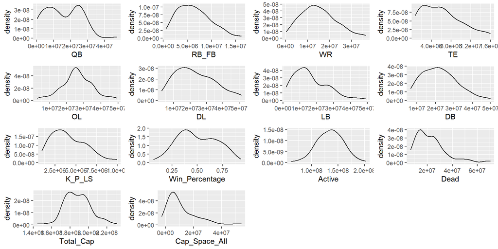

```r
dg1 <- ggplot(data = combined_data, aes(x = QB)) +
  geom_density()

dg2 <- ggplot(data = combined_data, aes(x = RB_FB)) +
  geom_density()

dg3 <- ggplot(data = combined_data, aes(x = WR)) +
  geom_density()

dg4 <- ggplot(data = combined_data, aes(x = TE)) +
  geom_density()

dg5 <- ggplot(data = combined_data, aes(x = OL)) +
  geom_density()

dg6 <- ggplot(data = combined_data, aes(x = DL)) +
  geom_density()

dg7 <- ggplot(data = combined_data, aes(x = LB)) +
  geom_density()

dg8 <- ggplot(data = combined_data, aes(x = DB)) +
  geom_density()

dg9 <- ggplot(data = combined_data, aes(x = K_P_LS)) +
  geom_density()

dg10 <- ggplot(data = combined_data, aes(Win_Percentage)) +
  geom_density()

dg11 <- ggplot(data = combined_data, aes(Active)) +
  geom_density()

dg12 <- ggplot(data = combined_data, aes(Dead)) +
  geom_density()

dg13 <- ggplot(data = combined_data, aes(Total_Cap)) +
  geom_density()

dg14 <- ggplot(data = combined_data, aes(Cap_Space_All)) +
  geom_density()

grid.arrange(dg1, dg2, dg3, dg4, dg5, dg6, dg7, dg8, dg9, dg10, dg11, dg12, dg13, dg14, ncol = 4)
```

## 3.3 **Bivariate Plot**

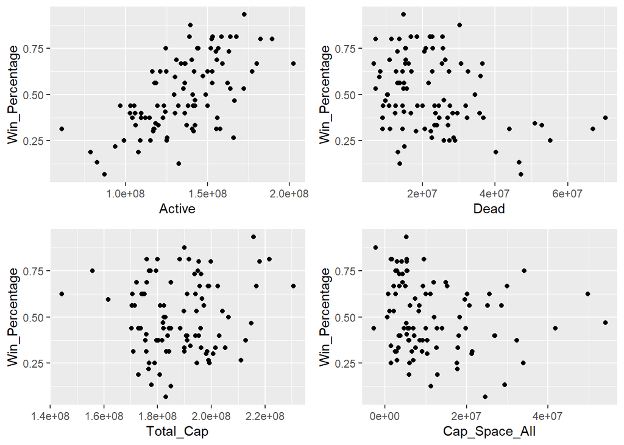

```r
os1 <- ggplot(data = combined_data, aes(x = Active, y = Win_Percentage)) +
  geom_point()

os2 <- ggplot(data = combined_data, aes(x = Dead, y = Win_Percentage)) +
  geom_point()

os3 <- ggplot(data = combined_data, aes(x = Total_Cap, y = Win_Percentage)) +
  geom_point()

os4 <- ggplot(data = combined_data, aes(x = Cap_Space_All, y = Win_Percentage)) +
  geom_point()

grid.arrange(os1, os2, os3, os4)
```

This bivariate plot represents the team’s overall spending. The plot, indicates that a team’s active money may have linear correlation to the win percentage in a season. As the amount of active money increases, the win percentage also increases. The other variables do not seem to have any significant visual correlation to win percentage.

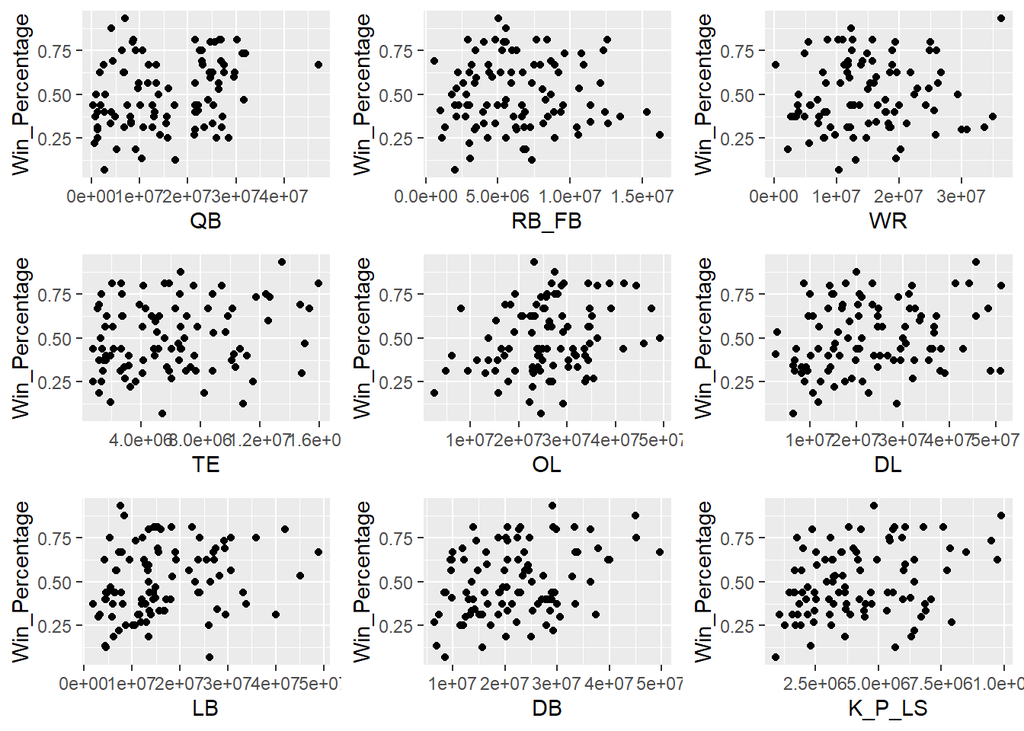

```r
eg_1 <- ggplot(data = combined_data, aes(x = QB, y = Win_Percentage)) +
  geom_point()

eg_2 <- ggplot(data = combined_data, aes(x = RB_FB, y = Win_Percentage)) +
  geom_point()

eg_3 <- ggplot(data = combined_data, aes(x = WR, y = Win_Percentage)) +
  geom_point()

eg_4 <- ggplot(data = combined_data, aes(x = TE, y = Win_Percentage)) +
  geom_point()

eg_5 <- ggplot(data = combined_data, aes(x = OL, y = Win_Percentage)) +
  geom_point()

eg_6 <- ggplot(data = combined_data, aes(x = DL, y = Win_Percentage)) +
  geom_point()

eg_7 <- ggplot(data = combined_data, aes(x = LB, y = Win_Percentage)) +
  geom_point()

eg_8 <- ggplot(data = combined_data, aes(x = DB, y = Win_Percentage)) +
  geom_point()

eg_9 <- ggplot(data = combined_data, aes(x = K_P_LS, y = Win_Percentage)) +
  geom_point()

grid.arrange(eg_1, eg_2, eg_3, eg_4, eg_5, eg_6, eg_7, eg_8, eg_9, ncol = 3)
```

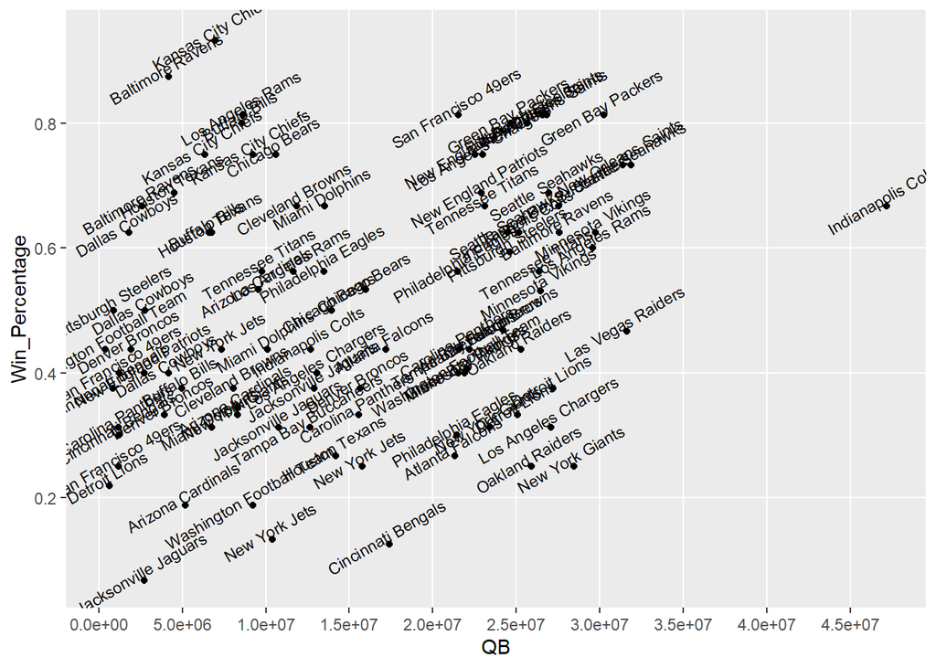

```r
ggplot(data = combined_data, aes(x = QB, y = Win_Percentage, label = Team)) +
  geom_point() +
  scale_y_continuous(breaks = seq(0, 1.0, 0.2), minor_breaks = F) +
  scale_x_continuous(breaks = seq(0, 50000000, 5000000), minor_breaks = F)+
  geom_text( size = 3, vjust = 0, nudge_y = 0.005, angle = 30)
```

The next bivariate plot shows the amount of money teams spend on the different positions. Possible linear correlations include the offensive line, defensive backs, and kickers/punters. A noticeable thing is the QB plot has an outlier on the far right of the plot. This spending is almost double of most teams. Doing further research, this point is in the 2020 season for the Indianapolis Colts team. They acquired Phillip Rivers over the offseason and in the prior season before gave Jacoby Brissett a contract extension for being a starter. Whiling keep both QBs on the roster, the amount spent become inflated compared to other teams.

# 4 *Linear Regression Model*

## 4.1 **Initial Model for Postional Spending**

```r
MLR <- lm(Win_Percentage ~ QB + RB_FB + WR + TE + OL + DL + LB + DB + K_P_LS, data = combined_data)

summary(MLR)
```

```
##
## Call:
## lm(formula = Win_Percentage ~ QB + RB_FB + WR + TE + OL + DL +
##     LB + DB + K_P_LS, data = combined_data)
##
## Residuals:
##      Min       1Q   Median       3Q      Max
## -0.34131 -0.10644 -0.02861  0.11095  0.31639
##
## Coefficients:
##               Estimate Std. Error t value Pr(>|t|)
## (Intercept) -2.213e-01  9.492e-02  -2.331 0.022066 *
## QB           4.265e-09  1.660e-09   2.569 0.011940 *
## RB_FB        3.000e-09  4.731e-09   0.634 0.527680
## WR           2.256e-09  2.072e-09   1.089 0.279085
## TE           2.016e-09  4.296e-09   0.469 0.640126
## OL           5.241e-09  1.817e-09   2.884 0.004960 **
## DL           4.417e-09  1.413e-09   3.125 0.002425 **
## LB           6.294e-09  1.621e-09   3.883 0.000202 ***
## DB           7.289e-09  1.728e-09   4.218 6.07e-05 ***
## K_P_LS       2.068e-08  7.894e-09   2.620 0.010397 *
## ---
## Signif. codes:  0 '***' 0.001 '**' 0.01 '*' 0.05 '.' 0.1 ' ' 1
##
## Residual standard error: 0.1516 on 86 degrees of freedom
## Multiple R-squared:  0.4597, Adjusted R-squared:  0.4032
## F-statistic: 8.132 on 9 and 86 DF,  p-value: 1.232e-08
```

## 4.2 **Reduced Model for Positional Spending**

```r
Reduced_MLR <- lm(Win_Percentage ~ QB + OL + DL + LB + DB + K_P_LS, data = combined_data)

summary(Reduced_MLR)
```

```
##
## Call:
## lm(formula = Win_Percentage ~ QB + OL + DL + LB + DB + K_P_LS,
##     data = combined_data)
##
## Residuals:
##      Min       1Q   Median       3Q      Max
## -0.33436 -0.11322 -0.02992  0.11310  0.36816
##
## Coefficients:
##               Estimate Std. Error t value Pr(>|t|)
## (Intercept) -1.660e-01  8.148e-02  -2.037 0.044622 *
## QB           4.429e-09  1.573e-09   2.816 0.005991 **
## OL           5.159e-09  1.796e-09   2.873 0.005088 **
## DL           4.760e-09  1.378e-09   3.455 0.000844 ***
## LB           6.278e-09  1.602e-09   3.920 0.000174 ***
## DB           7.407e-09  1.701e-09   4.354 3.56e-05 ***
## K_P_LS       2.048e-08  7.591e-09   2.698 0.008342 **
## ---
## Signif. codes:  0 '***' 0.001 '**' 0.01 '*' 0.05 '.' 0.1 ' ' 1
##
## Residual standard error: 0.1505 on 89 degrees of freedom
## Multiple R-squared:  0.4491, Adjusted R-squared:  0.412
## F-statistic: 12.09 on 6 and 89 DF,  p-value: 6.763e-10
```

## 4.3 **Residuals**

```r
#Create predictions based off MLR model

RM_pred <- predict(Reduced_MLR) #Reduced Model

#Create residuals of both models

Reduced_MLR_resid <- resid(Reduced_MLR)
```

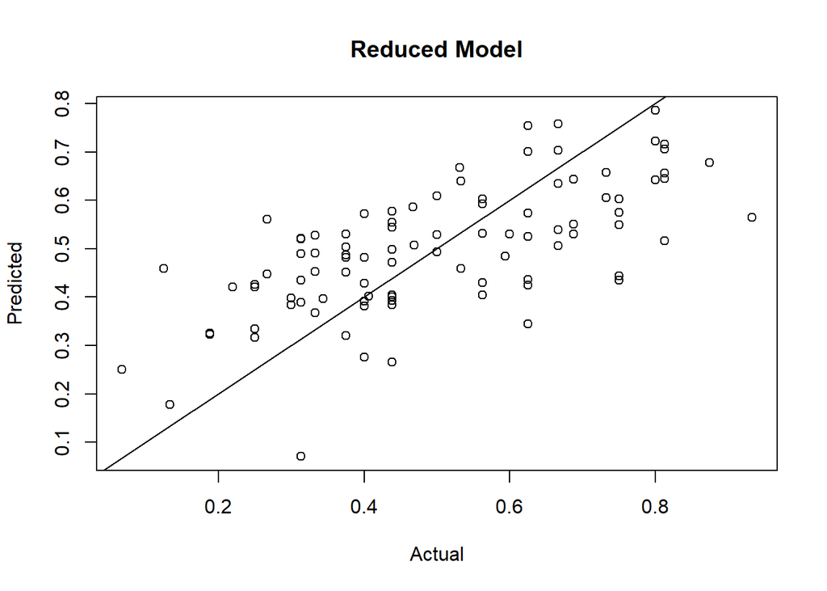

```r
#Plot Actual vs Predicted for Reduced Model

plot(combined_data$Win_Percentage, RM_pred,
     xlab = "Actual", ylab = "Predicted" , main = "Reduced Model")
abline(a=0,b=1)
```

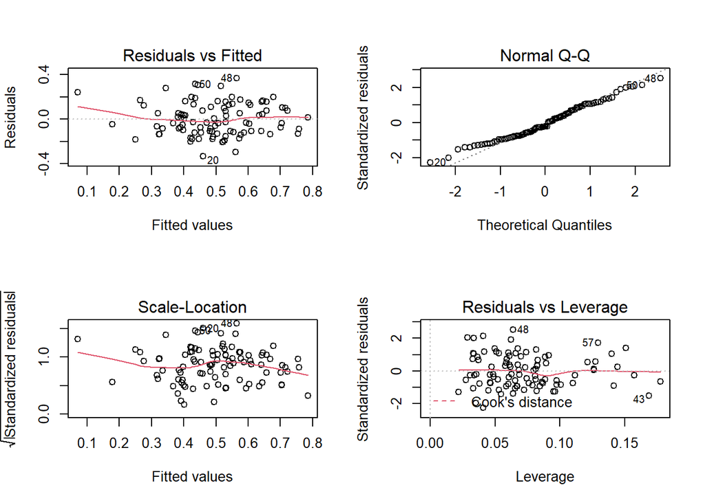

```r
#Plot Residuals for Reduced Model
par(mfrow=c(2,2))
plot(Reduced_MLR)
```

For this analysis, the goal is to create a linear regression model, calculating the win percentage based on the money a NFL team spends on each position. The initial model includes all the positions on the roster. After taking a look at the summary, a reduced model was created using only the statistically significant variables in the initial model. The multiple linear regression model has a R-squared value of 0.44 and a residual standard error of 0.15 on 89 degrees of freedom. The residuals show that the model is a mediocre fit for the data due to the variance it does not cover.

## 4.4 **Linear Model for Active Spending**

```r
Team_MLR <- lm(Win_Percentage ~ Active, data = combined_data)

summary(Team_MLR)
```

```
##
## Call:
## lm(formula = Win_Percentage ~ Active, data = combined_data)
##
## Residuals:
##      Min       1Q   Median       3Q      Max
## -0.38154 -0.10287 -0.01232  0.13699  0.35262
##
## Coefficients:
##               Estimate Std. Error t value Pr(>|t|)
## (Intercept) -1.444e-01  8.629e-02  -1.673   0.0976 .
## Active       4.779e-09  6.289e-10   7.599  2.2e-11 ***
## ---
## Signif. codes:  0 '***' 0.001 '**' 0.01 '*' 0.05 '.' 0.1 ' ' 1
##
## Residual standard error: 0.1553 on 94 degrees of freedom
## Multiple R-squared:  0.3805, Adjusted R-squared:  0.3739
## F-statistic: 57.74 on 1 and 94 DF,  p-value: 2.201e-11
```

A second linear regression model is created to show the correlation of active money spent on win percentage. The variable Active is statistically significant with win percentage but due the complex data, the model does not cover much of the variance found. This is indicated in the low R-squared value of 0.3805.

## 4.5 **Residuals for Active Spending**

```r
#Create predictions based off MLR model

Team_pred <- predict(Team_MLR) #Reduced Model

#Create residuals of both models

Reduced_MLR_resid <- resid(Team_MLR)
```

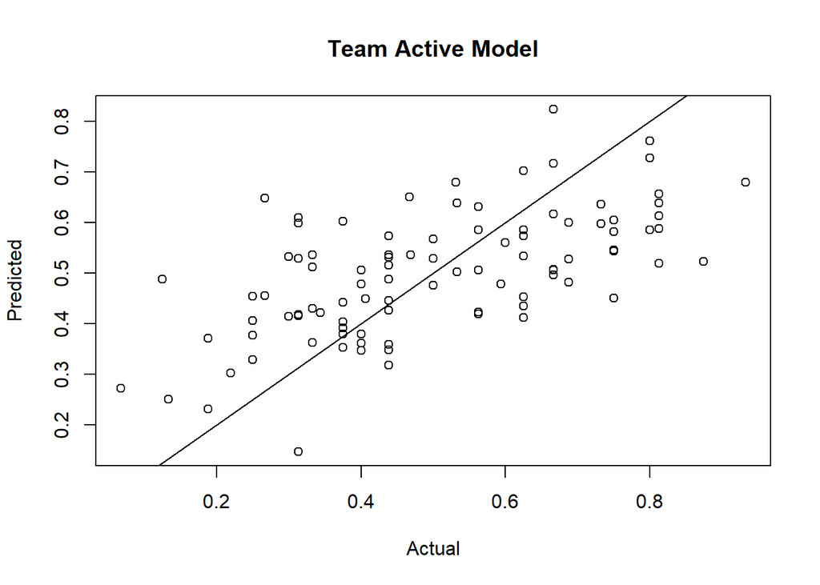

```r
#Plot Actual vs Predicted for Reduced Model

plot(combined_data$Win_Percentage, Team_pred,
     xlab = "Actual", ylab = "Predicted" , main = "Team Active Model")
abline(a=0,b=1)
```

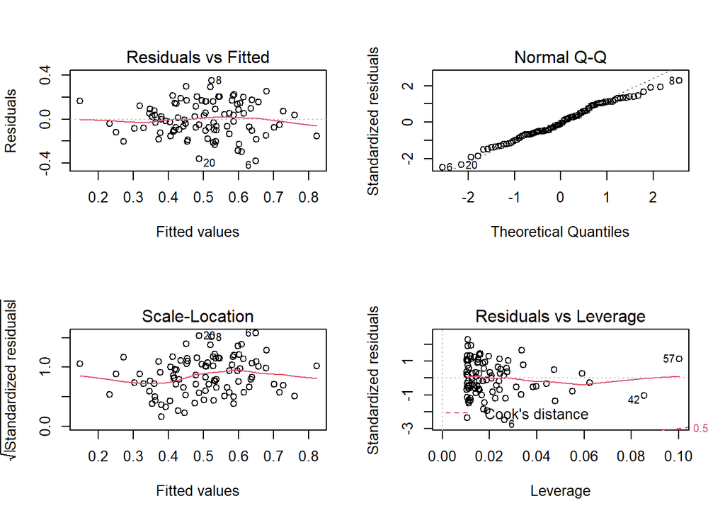

```r
#Plot Residuals for Reduced Model
par(mfrow=c(2,2))
plot(Team_MLR)
```

# 5 *Limitations and Application*

## 5.1 **Limitations**

There are a few noticeable limitations to this analysis. The first being that the data does not go into a deep dive on how money is allocated in each unique position. For example, if a team spends 25M on the offensive line for a year, the data does not indicate if most of that money is going to one star player or spread out evenly amongst many players. Secondly the data does not reflect injuries that could have happened throughout the season. Injuries could have a season altering effect on a team’s win percentage. For example, if a team spends 30M on a star QB but he is injured in week 1; and the team has a losing record. This unplanned outcome does not entirely reflect a team’s expectations coming into the season and the data that is historically recorded. The third limitation is the analysis does not account how deep the game really is. In a football game, there are many other factors than the 22 players on the field. This includes coaching, management, referees, and practice. Even with these limitations, this analysis can still be of use.

## 5.2 **Course of Action**

The linear models that were created throughout the analysis can still be of use. Teams can use the model to create realistic goals for their teams coming into the season. For example, a team that spends less money may make it their goal to rebuild and find new talent throughout the season. On the other hand, a team that spends a lot of money may make it their goal to reach the playoffs or win a Superbowl. The model may also be useful in off season planning by prioritizing money on statistically significant positions. One course of action is to spend less money on wide receivers and focus spending money on the defensive line. The model is far from perfect, but it still has some useful aspects to it.

## 5.3 **Ending**

Thank you for reading my analysis. This was a for fun project I wanted to do with a topic that interests me. I am pretty satisfied with the outcome of this project, as this was the first time, I scraped data off the internet and created my own analysis. Please comment any critiques or ideas you may have, and I will be sure to implement them in my next project.